# Statistical Computing

School of Economics and Management  
Beihang University  
http://yanfei.site

## General information

- **Credits:** 2 credits
- **Lecturer:** Yanfei Kang
- **Language:** Taught in Chinese. Materials are in English.
- **Computer language: R**
- **Reception hours:** Questions concerned with this course can be asked during or after each lecture or via email.
- **Lecture notes:** available on on https://yanfei.site/teaching/sc.

## References

1. [R programming for data science](https://bookdown.org/rdpeng/rprogdatascience/). Roger Peng. Leanpub. 2018.
2. [Advanced statistical computing](https://bookdown.org/rdpeng/rprogdatascience/). Roger Peng. 2018.
3. Introduction to scientific programming and simulation using R. Owen Jones, Robert Maillardet, Andrew Robinson. 2nd Edition. CRC press. 2014. ISBN: 9781466569997.

## Unit objectives

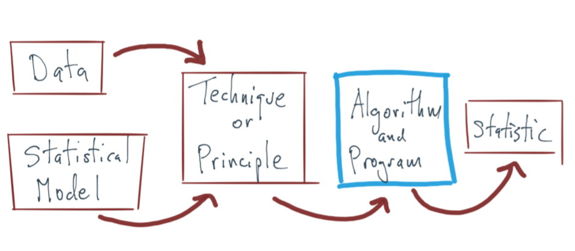

The process of statistical modeling.

## Unit objectives

1. Learn R programming for data science;
2. Learn optimization and simulation tools;
3. Develop computational linear algebra techniques, such as eigenanalysis and singular value decomposition and their applications.

## Examinations

- Assignments (labs): 40%
- Final exam: 60%

## About assignments

1. Subject of your email: "SC2019Lab-N-Name-StudentID".
2. Email attachments: R script named as "SC2019Lab-N-Name-StudentID.R".
3. **Pls let me know who you are.**
4. **Pls write a decent email.**

## Course contents

- R for data science
  - R basics
  - Managing data frames with the `dplyr` package
  - Control structures and functions
  - Dealing with text data
  - Debugging and Profiling R code
- Optimization
  - Newton's method
  - Quasi-Newton methods
  - Derivative free methods
- Computational Linear Algebra
  - Eigenanalysis
  - Singular value decomposition (SVD)
  - Applications of SVD
  - Numerical algorithms for eigenanalysis
- Simulation
  - Independent Monte Carlo
  - Markov Chain Monte Carlo